# Socio-economic indicators for 10 european countries in 2014 - 2020

Edyta Pszczółkowska, Anna Sikora

02 czerwiec, 2022

[figure not shown]

Spain

# Spain : socio-economic indicators 2015 - 2019

The aim of this report is to present the economy and social conditions in 2015 - 2019 .

Our analysis will be divided on four areas using the following variables:

- economy:
  - GDP per capita
  - Export as GDP percent
  - Import as GDP percent
  - RD as GDP percent - expenses on research and development expressed as % of GDP
- Population:
  - population
  - birth rate - total number of live births per 1,000 population
  - life expectation by 65
  - life expectation by birth
- Unemployment:
  - unemployment rate
  - long term unemployment
- Women situation:
  - fertility rate - total number of children that would be born to each woman if she were to live to the end of her child-bearing years
  - age at 1st child - mean age of women while giving a birth to 1st child
  - gender pay gap - average difference between the remuneration for men and women who are working expressed in %

The dataset was obtained from [Eurostat database](https://ec.europa.eu/eurostat/data/database).

# Topics

## Economy

### Import, export

GDP and the indicators dependent on it

|  | year | GDP mld $ | GDP per capita $ | Export as % of GDP | Import as % of GDP |
| --- | --- | --- | --- | --- | --- |
| 2 | 2015 | 1078.56 | 23220 | 33.6 | 30.6 |
| 3 | 2016 | 1113.63 | 23980 | 33.9 | 29.9 |
| 4 | 2017 | 1161.80 | 24970 | 35.1 | 31.5 |
| 5 | 2018 | 1201.46 | 25750 | 35.2 | 32.4 |
| 6 | 2019 | 1240.08 | 26420 | 35.0 | 32.0 |

From the table below we can conclude, that the GDP in the period 2015 - 2019 has changed by 14.98%.

Taking into account the change of population by 1.05% such a change in absolute GDP corresponds to change in GDP per capita by 13.78%.

The maximum and minimum export expressed as GDP percent was observed in 2018 and in 2015 respectively.

The maximum and minimum import expressed as GDP percent was observed in 2018 and in 2016 respectively.

### Expenses on R&D

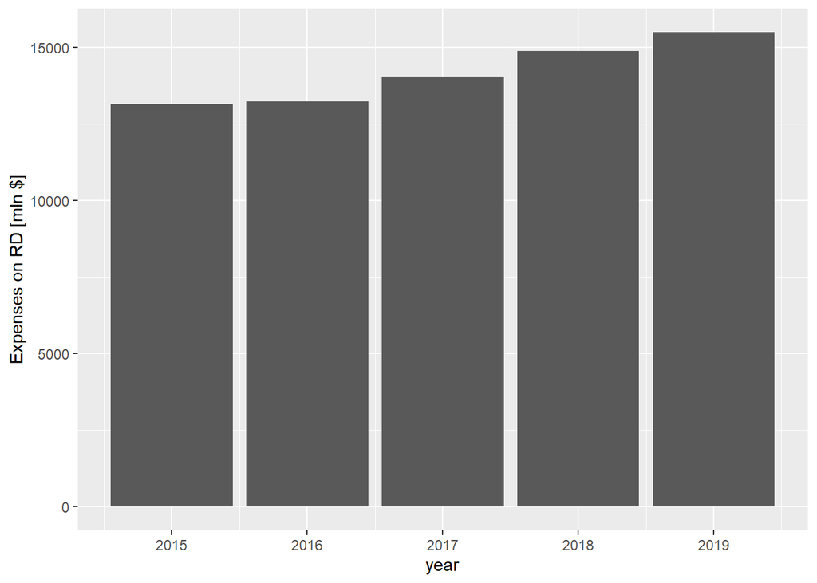

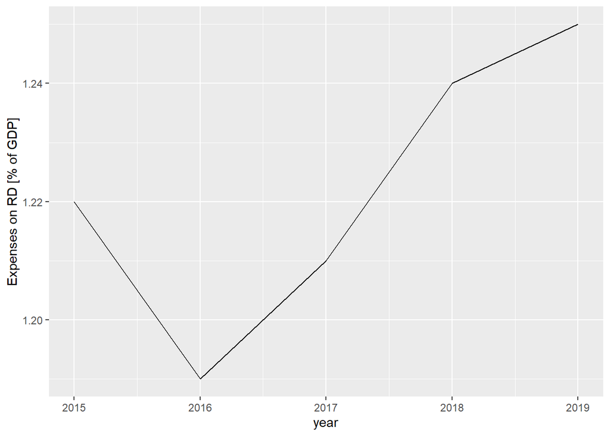

From the plot below we can conclude, that the expenses on R&D in the period 2015 - 2019 have changed by 0.03 % which corresponds to change by 2342.57 mln $ in expressed absolute terms.

## Population

### Population per Year

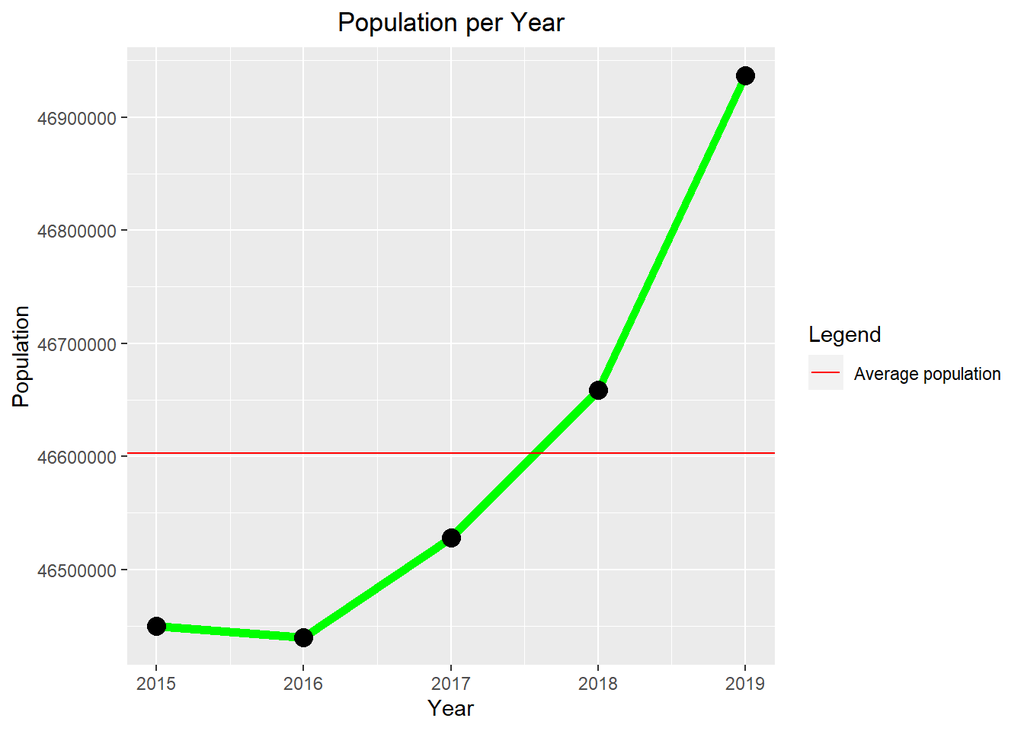

The average population between 2015 and 2019 in Spain was 46 milions.

The highest population in Spain was observed in year 2019.

The lowest population in Spain was observed in year 2016.

### Birth rate

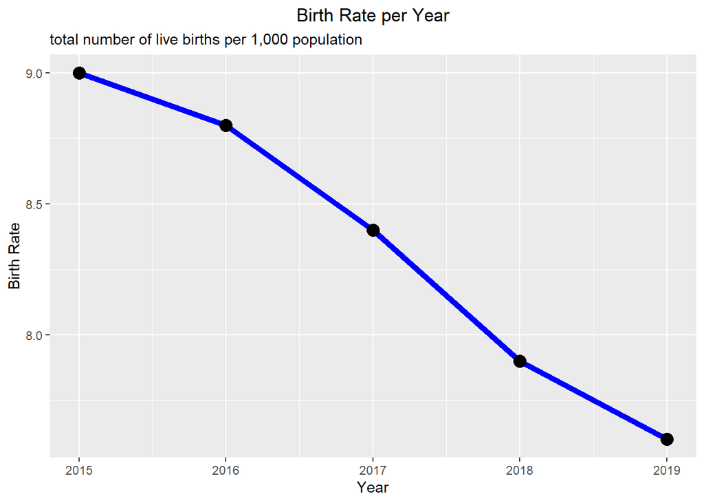

The highest birth rate in Spain was observed in year 2015.

The lowest birth rate in Spain was observed in year 2019.

### Life expectancy

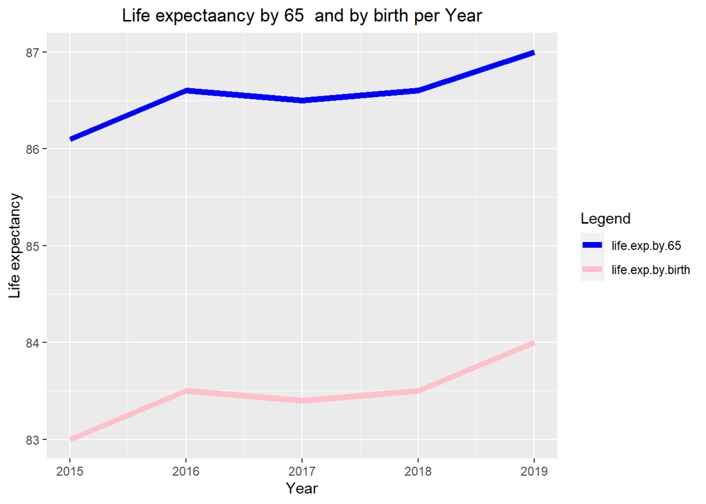

Life expectancy for people by 65 years old in 2015 was 86.

Life expectancy for people by 65 years old in 2019 was 87.

Life expectancy for people by birth in 2015 was 83.

Life expectancy for people by birth in 2019 was 84.

The average life expectancy between 2015 and 2019 for people by birth in Spain was 83.

## Unemployment

### Short and long term unemployment

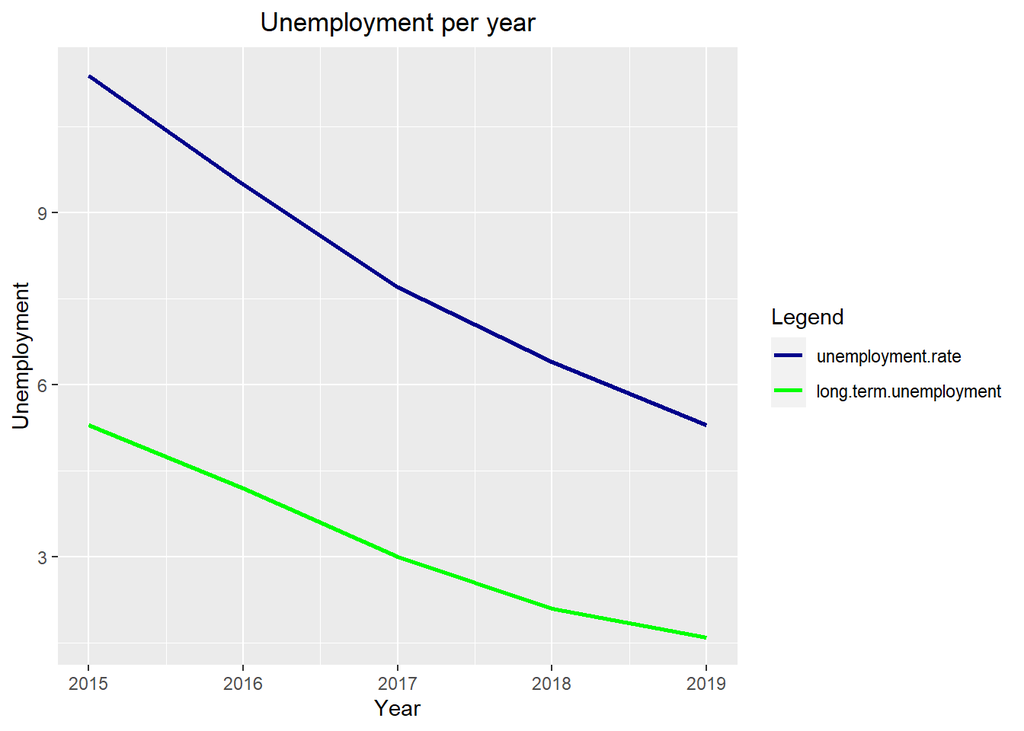

Unemployment rate in 2015 was 11.4.

Unemployment rate in 2019 was 5.3.

Long term unemployment rate in 2015 was 5.3.

Long term unemployment rate in 2019 was 1.6.

### Unemployment Table

Short term and long term unemployemt rate

|  | Year | Unemployment rate [%] | Long term unemployment rate [%] |
| --- | --- | --- | --- |
| 2 | 2015 | 11.4 | 5.3 |
| 3 | 2016 | 9.5 | 4.2 |
| 4 | 2017 | 7.7 | 3.0 |
| 5 | 2018 | 6.4 | 2.1 |
| 6 | 2019 | 5.3 | 1.6 |

## Women situation

### Fertility rate

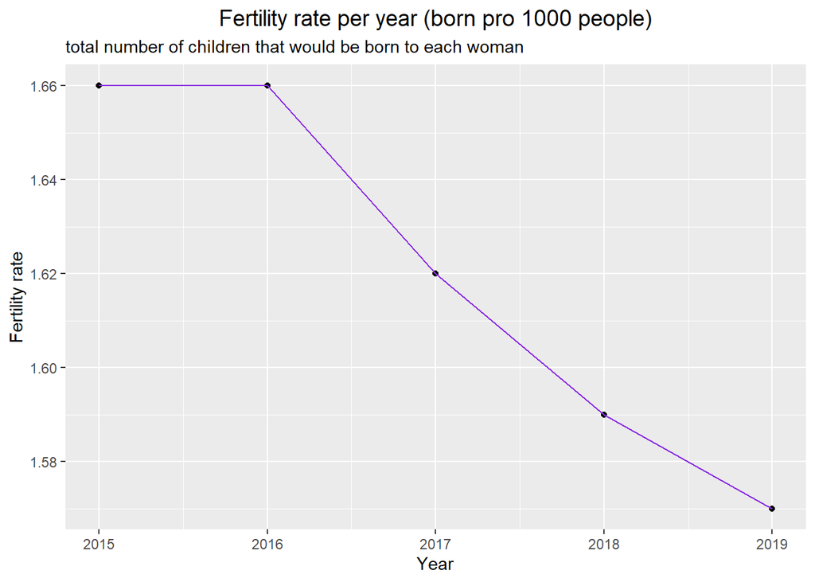

The average fertility rate between 2015 and 2019 in Spain was 2.

The highest fertility rate in Spain was observed in year 2015.

The lowest fertility rate in Spain was observed in year 2019.

### Age at first child

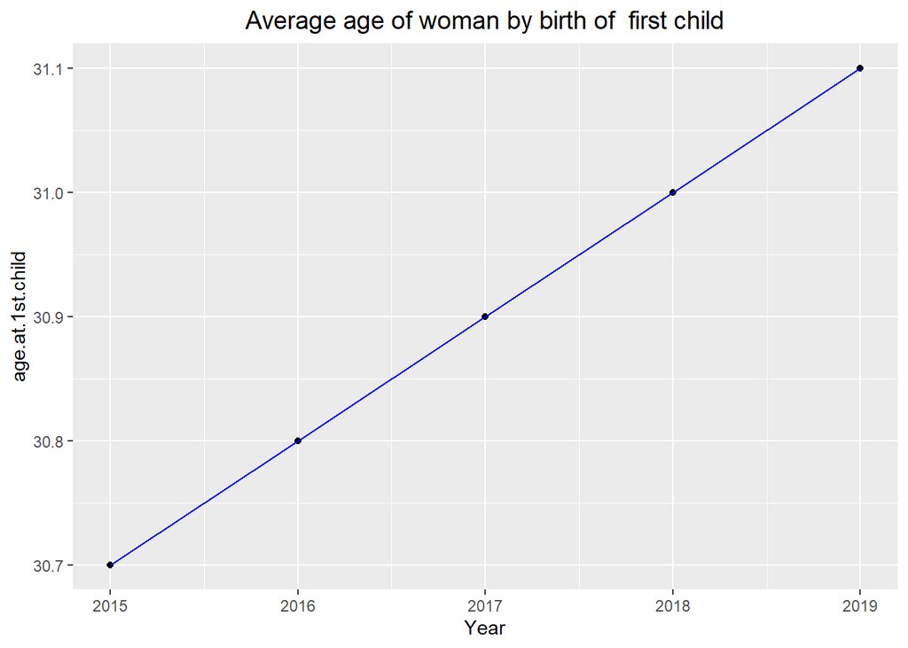

The average age of a woman while giving birth to the first child 2015 and 2019 in Spain was 31.

The highest average age of a woman while giving birth to the first child in Spain was observed in year 2019.

The lowest average age of a woman while giving birth to the first child in Spain was observed in year 2015.

### Gender pay gap

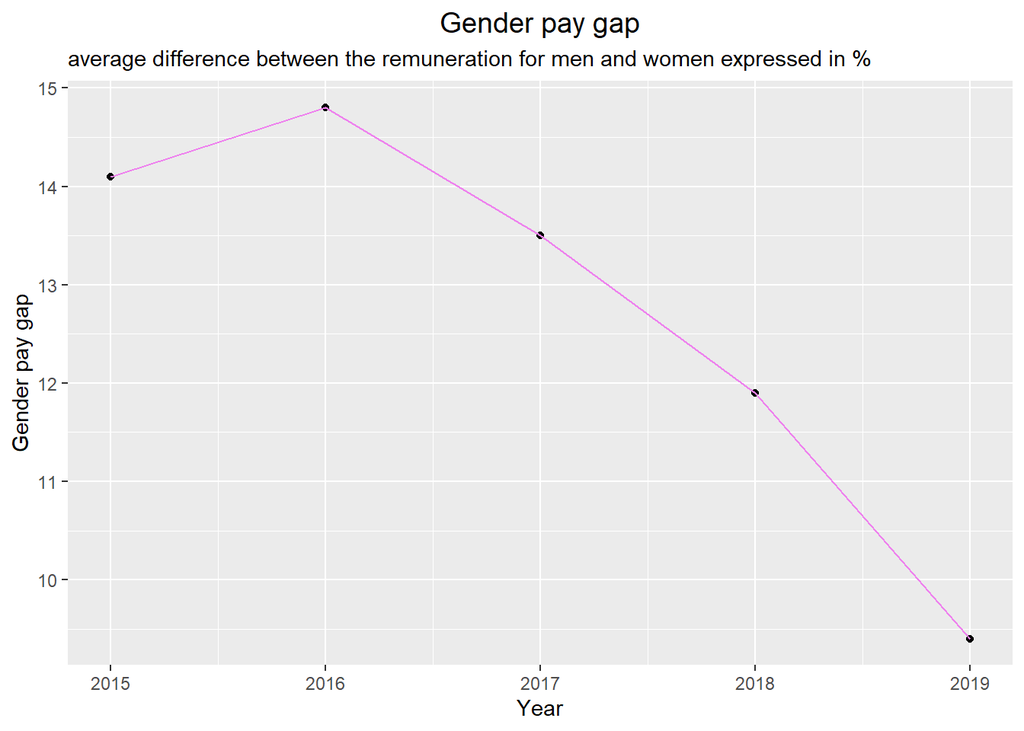

Gender pay gap is calculated as the average difference between the remuneration for men and women who are working. expressed in %.

The highest Gender pay gap in Spain was observed in year 2016.

The lowest Gender pay gap in Spain was observed in year 2019.